# Undersøk korpus med metadata

Notebook for å undersøke korpus med metadata.

En viktig metode i undersøkelse av metadata og tekster er grafer og nettverk.

```python
import dhlab.module_update as mu
import dhlab.nbtext as nb
import dhlab.token_map as tm
import dhlab.graph_networkx_louvain as gnl
```

```python
mu.css()
```

Bygg et korpus, en samling bøker basert på dewey - vi skal prøve samme øvelse også med emneord

```python
bøker = nb.book_corpus(
    period=(1950, 2010),
    #title='%',
    #subject='krig',
    ddk='335%', limit=300)
```

```python
bøker
```

|  | urn | author | title | year |
| --- | --- | --- | --- | --- |
| 0 | 2007072001069 | Aspelin, Gunnar | Karl Marx | 1971 |
| 1 | 2012100108077 | Barradas, Carlos | Karl Marx | 2009 |
| 2 | 2014030707099 | Mao, Zedong | Om motsigelsen | 1978 |
| 3 | 2007072704010 | Šik, Ota | Plan og marked | 1969 |
| 4 | 2007072400117 | Gravem, Peder | Kristendom og marxisme | 1977 |
| 5 | 2007110501012 | Marx, Karl | Skrifter om den materialistiske historieoppfat... | 1991 |
| 6 | 2014081508159 | Fine, Ben | Om Kapitalen av Marx | 2009 |
| 7 | 2012100208061 | Lenin, V.I. | Om ungdommen | 1977 |
| 8 | 2012110807138 | Pelikán, Jiří | vår uten ende | 1975 |
| 9 | 2013030506061 |  | Kapitalisme - sosialisme | 1981 |
| 10 | 2016060808149 | Lenin, V.I. | To slags taktikk for sosialdemokratiet i den d... | 1982 |
| 11 | 2007043001082 | Gjessing, Gutorm | Sosialisme og fred | 1965 |
| 12 | 2016052608160 |  | Hvorfor sosialisme? | 1979 |
| 13 | 2008062404097 | Trockij, Lev | permanente revolusjon | 1969 |
| 14 | 2007062104037 | Bahro, Rudolf | Alternativet | 1979 |
| 15 | 2007041801037 | Elster, Torolf | Inn i en ny verden | 1961 |
| 16 | 2008052701031 |  | KUL 2 år | 1975 |
| 17 | 2007071900090 | Fischer, Ernst | Hva Lenin egentlig sa | 1971 |
| 18 | 2013102406054 |  | Berlin-konferansen og våre oppgaver | 1977 |
| 19 | 2016110148037 |  | Anarkistisk lesebok | 1970 |
| 20 | 2014071808166 |  | Marxismen - kort innføring | 1976 |
| 21 | 2014121608106 | Kalheim, Ragnar | Alt for mennesket | 1963 |
| 22 | 2007060501049 | Brandt, Willy | Brev og samtaler 1972-1975 | 1976 |
| 23 | 2011101408136 | Marx, Karl | Verker i utvalg | 1970 |
| 24 | 2007070204013 | Anderson, Gidske | Fra stalinisme til sosialdemokrati? | 1979 |
| 25 | 2006110301012 |  | Sosialisme på norsk | 1981 |
| 26 | 2015021308033 |  | Leninismens plass i marxismen | 1976 |
| 27 | 2016053108093 | Marx, Karl | Anarkisme og anarko-syndikalisme | 1976 |
| 28 | 2007072700015 | Djilas, Milovan | Det ufullkomne samfunn | 1969 |
| 29 | 2008052804073 | Berntsen, Harald | historiske materialismen og dens historiske be... | 1976 |
| ... | ... | ... | ... | ... |
| 149 | 2011102608063 | Lenin, V.I. | Hva må gjøres? | 1970 |
| 150 | 2011102508232 | Marx, Karl | Verker i utvalg | 1970 |
| 151 | 2007070201007 | Holm, Harald | Statsmonopolkapitalismen og inntektspolitikken | 1978 |
| 152 | 2008100804001 | Ustvedt, Yngvar | De store anarkister | 1977 |
| 153 | 2012031308152 | Holm, Harald | Innføring i politisk økonomi | 1973 |
| 154 | 2007072400107 | Svensson, Jörn | Du skal ta ledelsen og makten | 1977 |
| 155 | 2012110108069 | Marx, Karl | Kapitalen | 1983 |
| 156 | 2016052708003 | Claudín, Fernando | Eurokommunisme og socialisme | 1978 |
| 157 | 2014022605060 | Marx, Karl | Kapitalen | 1983 |
| 158 | 2007052100050 | Petersen, Carl Heinrich | Kommunismens kjettere | 1965 |
| 159 | 2008052304014 | Mandel, Ernest | Seinkapitalismen | 1975 |
| 160 | 2013031205029 | Lenin, V.I. | Imperialismen som kapitalismens høyeste stadium | 2006 |
| 161 | 2014082508255 |  | Grunnsirkel i marxismen - leninismen | 1974 |
| 162 | 2007053101001 | Pannekoek, Anton | Parti, råd, revolusjon | 1975 |
| 163 | 2007071901032 | Sætra, Hartvig | Populismen i norsk sosialisme | 1971 |
| 164 | 2007073001121 | Enerstvedt, Regi Th. | Dialektikk og samfunnsvitenskap | 1969 |
| 165 | 2015073008011 |  | Marx-Engels-leksikon | 2010 |
| 166 | 2007053001006 | Christophersen, Jens A. | Verdensrevolusjonen som ble vekk | 1968 |
| 167 | 2013041606007 | Kleven, Hans I. | herskende klasse | 1976 |
| 168 | 2013041906043 | Kleven, Hans I. | herskende klasse | 1976 |
| 169 | 2013121908188 | Marx, Karl | Kritikk av Gothaprogrammet | 1977 |
| 170 | 2010111606071 | Svensson, Per | Hvorfra, hvorhen | 1964 |
| 171 | 2007062900068 | Lamennais, Felicité Robert de | troendes tale | 1978 |
| 172 | 2012112808029 |  | Polens arbeidere reiser seg | 1977 |
| 173 | 2007092401072 | Nilsen, Fritz | Norsk sosialisme - hva nå? | 1991 |
| 174 | 2007070300039 | Brøgger, Jan | Marxismen | 1978 |
| 175 | 2012011808228 |  | Leve det proletariske diktaturets seier | 1971 |
| 176 | 2016112908115 |  | Sosialiserings-spørsmålet | 1961 |
| 177 | 2007043004014 | Marx, Karl | Samfunn og frihet | 1965 |
| 178 | 2007072300076 |  | Sosialimperialismen | 1975 |

179 rows × 4 columns

## Undersøk forskjeller

Her samler vi sammen alle bøkene i korpus og summerer. Men først la oss se på en del av korpuset som en dokument term matrise

```python
# tar de fem første og henter frekvensene for alle bøkene

bøker_dtm = nb.get_corpus_text(nb.pure_urn(bøker)[:5])
```

```python
bøker_dtm
```

|  | 2007072001069 | 2012100108077 | 2014030707099 | 2007072704010 | 2007072400117 |
| --- | --- | --- | --- | --- | --- |
| . | 3764.0 | 39.0 | 767.0 | 2197.0 | 2951.0 |
| , | 2363.0 | 29.0 | 832.0 | 1281.0 | 1854.0 |
| og | 1657.0 | 16.0 | 667.0 | 1336.0 | 1174.0 |
| som | 1591.0 | 13.0 | 244.0 | 999.0 | 853.0 |
| i | 1348.0 | 12.0 | 596.0 | 1286.0 | 916.0 |
| den | 1309.0 | 11.0 | 348.0 | 702.0 | 507.0 |
| av | 1191.0 | 6.0 | 248.0 | 1357.0 | 628.0 |
| en | 1122.0 | 5.0 | 230.0 | 1239.0 | 577.0 |
| til | 912.0 | 5.0 | 358.0 | 781.0 | 541.0 |
| er | 887.0 | 15.0 | 346.0 | 891.0 | 1139.0 |
| det | 872.0 | 9.0 | 459.0 | 812.0 | 801.0 |
| for | 767.0 | 11.0 | 153.0 | 791.0 | 530.0 |
| på | 663.0 | 5.0 | 125.0 | 592.0 | 441.0 |
| « | 649.0 | 2.0 | 57.0 | 76.0 | NaN |
| å | 649.0 | 9.0 | 189.0 | 699.0 | 582.0 |
| med | 644.0 | 9.0 | 112.0 | 400.0 | 297.0 |
| » | 616.0 | 2.0 | 55.0 | 82.0 | NaN |
| de | 596.0 | 3.0 | 257.0 | 789.0 | 237.0 |
| et | 561.0 | 5.0 | 63.0 | 337.0 | 259.0 |
| ikke | 527.0 | 5.0 | 166.0 | 587.0 | 391.0 |
| s | 518.0 | NaN | 53.0 | 23.0 | 530.0 |
| Marx | 492.0 | 7.0 | 23.0 | 13.0 | 401.0 |
| han | 451.0 | NaN | 34.0 | 24.0 | 200.0 |
| at | 439.0 | 6.0 | 194.0 | 884.0 | 590.0 |
| kan | 428.0 | 2.0 | 69.0 | 351.0 | 269.0 |
| seg | 424.0 | 2.0 | 149.0 | 146.0 | 199.0 |
| har | 418.0 | 9.0 | 93.0 | 334.0 | 313.0 |
| ( | 336.0 | 2.0 | 60.0 | 145.0 | 596.0 |
| ) | 336.0 | 16.0 | 61.0 | 238.0 | 664.0 |
| eller | 331.0 | 4.0 | 73.0 | 177.0 | 116.0 |
| ... | ... | ... | ... | ... | ... |
| øst-vest- | NaN | NaN | NaN | 1.0 | NaN |
| østblokk-landene | NaN | NaN | NaN | NaN | 1.0 |
| østblokken | NaN | NaN | NaN | 6.0 | NaN |
| østblokken, | NaN | NaN | NaN | 1.0 | NaN |
| østerrikske | NaN | NaN | NaN | 1.0 | NaN |
| østeuropeisk | NaN | NaN | NaN | NaN | 3.0 |
| østeuropeiske | NaN | NaN | NaN | 1.0 | NaN |
| østhandel | NaN | NaN | NaN | 1.0 | NaN |
| østhandelen | NaN | NaN | NaN | 2.0 | NaN |
| østlige | NaN | NaN | NaN | 4.0 | 1.0 |
| østre | NaN | NaN | 1.0 | NaN | NaN |
| østvalutaens | NaN | NaN | NaN | 1.0 | NaN |
| øve | NaN | NaN | NaN | 2.0 | NaN |
| øye | NaN | NaN | 1.0 | NaN | NaN |
| øyeblikk | NaN | NaN | 1.0 | NaN | NaN |
| øyeblikkelig | NaN | NaN | 1.0 | 1.0 | NaN |
| øyeblikket | NaN | NaN | 2.0 | 1.0 | NaN |
| übegrensa | NaN | NaN | 1.0 | NaN | NaN |
| übegrunnbar | NaN | NaN | NaN | NaN | 1.0 |
| übegrunnbart | NaN | NaN | NaN | NaN | 1.0 |
| übegrunnede | NaN | NaN | NaN | NaN | 1.0 |
| übegrunnet | NaN | NaN | NaN | NaN | 1.0 |
| über | NaN | NaN | NaN | NaN | 1.0 |
| überettiget | NaN | NaN | NaN | NaN | 1.0 |
| übesluttsomhet | NaN | NaN | NaN | 1.0 | NaN |
| übesvart | NaN | NaN | NaN | 1.0 | NaN |
| übetinga | NaN | NaN | 2.0 | NaN | NaN |
| übrytelige | NaN | NaN | NaN | NaN | 2.0 |
| ™ | NaN | NaN | 1.0 | NaN | NaN |
| ■ | NaN | NaN | NaN | 2.0 | 2.0 |

18985 rows × 5 columns

Et varmekart gjør det enklere å spotte likhet og variasjon i tallene.

```python
nb.heatmap(bøker_dtm.head(50), color='#045599')
```

|  | 2007072001069 | 2012100108077 | 2014030707099 | 2007072704010 | 2007072400117 |
| --- | --- | --- | --- | --- | --- |
| . | 3764 | 39 | 767 | 2197 | 2951 |
| , | 2363 | 29 | 832 | 1281 | 1854 |
| og | 1657 | 16 | 667 | 1336 | 1174 |
| som | 1591 | 13 | 244 | 999 | 853 |
| i | 1348 | 12 | 596 | 1286 | 916 |
| den | 1309 | 11 | 348 | 702 | 507 |
| av | 1191 | 6 | 248 | 1357 | 628 |
| en | 1122 | 5 | 230 | 1239 | 577 |
| til | 912 | 5 | 358 | 781 | 541 |
| er | 887 | 15 | 346 | 891 | 1139 |
| det | 872 | 9 | 459 | 812 | 801 |
| for | 767 | 11 | 153 | 791 | 530 |
| på | 663 | 5 | 125 | 592 | 441 |
| « | 649 | 2 | 57 | 76 | 0 |
| å | 649 | 9 | 189 | 699 | 582 |
| med | 644 | 9 | 112 | 400 | 297 |
| » | 616 | 2 | 55 | 82 | 0 |
| de | 596 | 3 | 257 | 789 | 237 |
| et | 561 | 5 | 63 | 337 | 259 |
| ikke | 527 | 5 | 166 | 587 | 391 |
| s | 518 | 0 | 53 | 23 | 530 |
| Marx | 492 | 7 | 23 | 13 | 401 |
| han | 451 | 0 | 34 | 24 | 200 |
| at | 439 | 6 | 194 | 884 | 590 |
| kan | 428 | 2 | 69 | 351 | 269 |
| seg | 424 | 2 | 149 | 146 | 199 |
| har | 418 | 9 | 93 | 334 | 313 |
| ( | 336 | 2 | 60 | 145 | 596 |
| ) | 336 | 16 | 61 | 238 | 664 |
| eller | 331 | 4 | 73 | 177 | 116 |
| om | 312 | 6 | 85 | 234 | 339 |
| fra | 304 | 1 | 65 | 149 | 234 |
| Men | 282 | 0 | 40 | 9 | 137 |
| : | 276 | 4 | 31 | 59 | 314 |
| I | 223 | 2 | 56 | 173 | 206 |
| må | 217 | 0 | 58 | 273 | 107 |
| F | 215 | 1 | 0 | 1 | 6 |
| bare | 213 | 0 | 43 | 136 | 96 |
| denne | 211 | 2 | 48 | 190 | 109 |
| sin | 211 | 1 | 20 | 33 | 156 |
| vi | 209 | 5 | 123 | 88 | 257 |
| men | 198 | 2 | 43 | 99 | 67 |
| man | 194 | 0 | 0 | 2 | 8 |
| Det | 188 | 4 | 78 | 187 | 245 |
| Den | 175 | 2 | 41 | 88 | 122 |
| hans | 173 | 0 | 4 | 10 | 116 |
| mot | 163 | 0 | 40 | 29 | 80 |
| mellom | 161 | 1 | 143 | 216 | 151 |
| Han | 147 | 0 | 13 | 5 | 46 |
| dette | 147 | 0 | 48 | 171 | 124 |

```python
bøker_agg = nb.aggregate_urns(nb.pure_urn(bøker))
```

Så konverteres listen over ord og tall til en dataramme

```python
bøker_df = nb.frame_sort(nb.frame(bøker_agg, 'count'))
```

For referanse henter vi ut de 50000 mest frekvente ordene i bokhylla.

```python
totals = nb.frame(nb.totals(50000), 'tot')
```

Sånn ser frekvensene ut for bøkene

```python
bøker_df.head(20)
```

|  | count |
| --- | --- |
| , | 485488 |
| . | 431913 |
| og | 299126 |
| i | 277009 |
| som | 197925 |
| av | 189300 |
| den | 179799 |
| det | 177978 |
| er | 168222 |
| til | 152398 |
| en | 146932 |
| for | 126346 |
| å | 119078 |
| de | 119036 |
| at | 114580 |
| på | 95127 |
| ikke | 86514 |
| » | 86007 |
| « | 83787 |
| med | 80171 |

.. og sånn for bokhylla

```python
totals.head(20)
```

|  | tot |
| --- | --- |
| . | 1265723110 |
| , | 1105303412 |
| og | 543432056 |
| i | 460246057 |
| det | 273411583 |
| som | 265144740 |
| til | 254500136 |
| er | 248764786 |
| av | 235180661 |
| en | 231631623 |
| på | 205990369 |
| for | 202452659 |
| at | 199527660 |
| - | 195716474 |
| å | 184201667 |
| med | 182427175 |
| ) | 172258528 |
| var | 153392365 |
| ? | 151860120 |
| den | 151216998 |

Vi finner forskjellen ved å dividere den ene på den andre:

```python
forskjell = bøker_df['count']/totals['tot']
```

Tallene må sorteres, de høyeste tolkes til å være de mest relevante

```python
bøker_typiske_ord = nb.frame_sort(nb.frame(forskjell, 'ratio'))
bøker_typiske_ord.head(50)
```

|  | ratio |
| --- | --- |
| proletariatets | 0.149739 |
| proletariatet | 0.145173 |
| Engels | 0.099062 |
| kapitalens | 0.098061 |
| kapitalistiske | 0.083680 |
| Marx | 0.076045 |
| sosialismen | 0.074794 |
| kapitalismen | 0.074625 |
| marxismen | 0.067131 |
| borgerskapet | 0.064280 |
| borgerskapets | 0.061855 |
| arbeideren | 0.060015 |
| kapitalismens | 0.056702 |
| arbeiderklassens | 0.056064 |
| Lenin | 0.054539 |
| Lenins | 0.054271 |
| diktatur | 0.053092 |
| marxistiske | 0.050151 |
| revolusjonære | 0.048577 |
| Kapitalen | 0.047969 |
| utbytting | 0.047947 |
| kapitalistisk | 0.046798 |
| sosialistiske | 0.046419 |
| arbeiderklassen | 0.044652 |
| reaksjonære | 0.043502 |
| sosialisme | 0.041650 |
| revolusjonær | 0.040483 |
| kommunistiske | 0.040472 |
| dialektiske | 0.035996 |
| revolusjonens | 0.035095 |
| kapitalisme | 0.034840 |
| NKP | 0.034010 |
| kommunismen | 0.034001 |
| sosialistisk | 0.033829 |
| massene | 0.031288 |
| kapitalen | 0.030761 |
| herskende | 0.030497 |
| kommunisme | 0.030207 |
| arbeidsdelingen | 0.028718 |
| klasses | 0.028618 |
| arbeidende | 0.028480 |
| profitt | 0.028361 |
| materialisme | 0.028066 |
| arbeidsprosessen | 0.027724 |
| samfunnsmessige | 0.027595 |
| sosialister | 0.027144 |
| borgerlige | 0.027016 |
| dialektikk | 0.026760 |
| marxistisk | 0.026723 |
| arbeidsdagen | 0.026396 |

Som ordsky

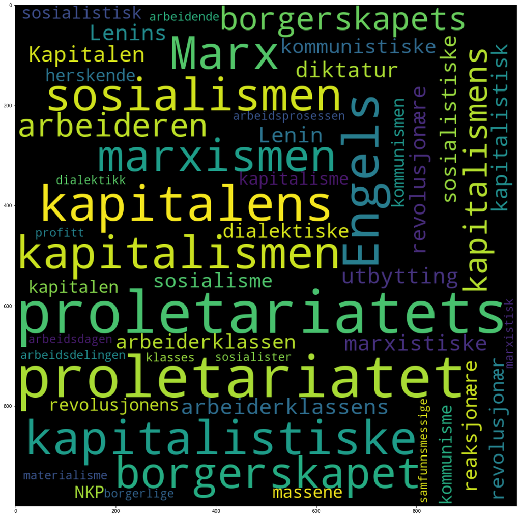

```python
nb.cloud(bøker_typiske_ord.head(50))
```

# Metadata for korpuset kan raskt sjekkes

Pass på at ikke korpuset er for stort (mange tusen).

```python
nb.frame(nb.metadata(nb.pure_urn(bøker)), 'urn forfatter år tittel subtittel forlag sjanger sesamid språk'.split())
```

|  | urn | forfatter | år | tittel | subtittel | forlag | sjanger | sesamid | språk | 9 |
| --- | --- | --- | --- | --- | --- | --- | --- | --- | --- | --- |
| 0 | 2007072001069 | Aspelin, Gunnar | 1971 | Karl Marx | samfunnsforsker og samfunnskritiker : en komme... | Tiden | notfiction | 06d8e058da7f680a1ff948918f106986 | nob | swe |
| 1 | 2012100108077 | Barradas, Carlos | 2009 | Karl Marx | Kapitalen med bobler | Rødt! | notfiction | d6380c0da5a5cdd1a5d7bc824a08d675 | nob |  |
| 2 | 2014030707099 | Mao, Zedong | 1978 | Om motsigelsen |  | Oktober | notfiction | 67f263e8ef6049d8966b893e4d50b325 | nob | engchi |
| 3 | 2007072704010 | Šik, Ota | 1969 | Plan og marked | markedsmekanismen i en sosialistisk planøkonomi | Aschehoug | notfiction | 9811a5d0773d0175c3d49bc289c51407 | nob | cze |
| 4 | 2007072400117 | Gravem, Peder | 1977 | Kristendom og marxisme | en konfrontasjon mellom kristent og marxistisk... | Credo/Luther | notfiction | 65c244b7337511520771d06ef494fe7c | nob |  |
| 5 | 2007110501012 | Marx, Karl | 1991 | Skrifter om den materialistiske historieoppfat... |  | Pax;Lobo | notfiction | 110ec43326ef0f171214bc146605d55f | nob | rus |
| 6 | 2014081508159 | Fine, Ben | 2009 | Om Kapitalen av Marx |  | Rødt! | notfiction | 9a13f409daba6b62fab7ffde3bb5aefa | nob | eng |
| 7 | 2012100208061 | Lenin, V.I. | 1977 | Om ungdommen |  | Oktober | notfiction | f25b47622fd000b9a7f1e5901bb2b85c | nob |  |
| 8 | 2012110807138 | Pelikán, Jiří | 1975 | vår uten ende |  | Pax | notfiction | 224676e98816d30a8faa7a5b2c9da69d | nob | fre |
| 9 | 2013030506061 |  | 1981 | Kapitalisme - sosialisme | studiebok fra AKP (m-l) | Oktober | notfiction | 2ba72f3c258b0d51136338bf84b22b18 | nob |  |
| 10 | 2016060808149 | Lenin, V.I. | 1982 | To slags taktikk for sosialdemokratiet i den d... |  | Falken | notfiction | a8f42f0a23529126ab6873ad4f8d8bc5 | nob | rus |
| 11 | 2007043001082 | Gjessing, Gutorm | 1965 | Sosialisme og fred |  | Pax | notfiction | 8703751cef4e5102630ba216d7471b03 | mul |  |
| 12 | 2016052608160 |  | 1979 | Hvorfor sosialisme? | studiebok | Oktober | notfiction | d98564a064df375da09f16919ab50411 | nob |  |
| 13 | 2008062404097 | Trockij, Lev | 1969 | permanente revolusjon |  | Pax | notfiction | 5ae2fbaee5ced30beca51b8eb001c33f | nob | rus |
| 14 | 2007062104037 | Bahro, Rudolf | 1979 | Alternativet | til kritikken av [!] den faktisk eksisterende ... | Pax | notfiction | 6c77f2290c33e0f80c66ee26f694d27c | mul | ger |
| 15 | 2007041801037 | Elster, Torolf | 1961 | Inn i en ny verden |  | Arbeidernes ungdomsfylking | notfiction | 0afdaca6986b4eb0040d86670b0ce28a | nob |  |
| 16 | 2008052701031 |  | 1975 | KUL 2 år |  | Kommunistisk universitetslag | notfiction | 3835ec06a1264a2105d75f9fcc657cc4 | nob |  |
| 17 | 2007071900090 | Fischer, Ernst | 1971 | Hva Lenin egentlig sa |  | Gyldendal | notfiction | e62d39158e819cf293aff422dc4ceab0 | nob | ger |
| 18 | 2013102406054 |  | 1977 | Berlin-konferansen og våre oppgaver | [temahefte] | NKP : i kommisjon hos Ny dag | notfiction | 8b1db11f385153d862a8aeffb61f3e48 | nob |  |
| 19 | 2016110148037 |  | 1970 | Anarkistisk lesebok | en antologi | Pax | notfiction | 127c65966396b73cf4f16477133ef8d3 | nob |  |
| 20 | 2014071808166 |  | 1976 | Marxismen - kort innføring |  | (Ny dag) | notfiction | de44b6fc052d0899901723ff6613d7fd | nob |  |
| 21 | 2014121608106 | Kalheim, Ragnar | 1963 | Alt for mennesket |  | Alt for mennesket | notfiction | 43490db38f66e6b341009ce126aba82a | nob |  |
| 22 | 2007060501049 | Brandt, Willy | 1976 | Brev og samtaler 1972-1975 |  | Tiden | notfiction | abe9ce5a076c4330da07a7844e44b344 | nob | ger |
| 23 | 2011101408136 | Marx, Karl | 1970 | Verker i utvalg |  | Pax;Oslo : Pax, c1970-1971 | unknown | 9de1d5046a786f80ac67370921480cdb | nob |  |
| 24 | 2007070204013 | Anderson, Gidske | 1979 | Fra stalinisme til sosialdemokrati? | politiske strømninger i Sør-Europa | Fabritius | notfiction | 16bd7cb12f0b018fcbd957b3081f203d | nob |  |
| 25 | 2006110301012 |  | 1981 | Sosialisme på norsk |  | Pax | notfiction | c6fcb1dfd1c7332ac2f7ea7ad33cf718 | nob |  |
| 26 | 2015021308033 |  | 1976 | Leninismens plass i marxismen | et debatthefte | Forbundet | notfiction | d6cf8c5b51675e02d11eb57f8dd045c8 | nob |  |
| 27 | 2016053108093 | Marx, Karl | 1976 | Anarkisme og anarko-syndikalisme |  | Ny dag | notfiction | 477f3f72786fdce7ee024280aa9d48e9 | nob |  |
| 28 | 2007072700015 | Djilas, Milovan | 1969 | Det ufullkomne samfunn | hinsides den nye klasse | Gyldendal | notfiction | 157b8fe2a9eef0709a542398ea3743dd | nob | enghrv |
| 29 | 2008052804073 | Berntsen, Harald | 1976 | historiske materialismen og dens historiske be... |  | Gyldendal | notfiction | 9b68a06c83fc38ca406c388e67bde174 | nob |  |
| ... | ... | ... | ... | ... | ... | ... | ... | ... | ... | ... |
| 149 | 2011102608063 | Lenin, V.I. | 1970 | Hva må gjøres? | brennende spørsmål i vår bevegelse | Ny Dag | notfiction | 18300346c30d5ec2e33b1178619795d4 | nob | rus |
| 150 | 2011102508232 | Marx, Karl | 1970 | Verker i utvalg |  | Pax;Oslo : Pax, c1970-1971 | unknown | c33719d5acf1ebba82c98c678fc9a8a2 | nob |  |
| 151 | 2007070201007 | Holm, Harald | 1978 | Statsmonopolkapitalismen og inntektspolitikken |  | Ny dag | notfiction | a9277dff9a5f56c97d16fe9589bdf3aa | nob |  |
| 152 | 2008100804001 | Ustvedt, Yngvar | 1977 | De store anarkister |  | Tiden;Emil Moestue | notfiction | a8120cef3ba5b2c7cbb4311c0a0b7ca0 | nob |  |
| 153 | 2012031308152 | Holm, Harald | 1973 | Innføring i politisk økonomi |  | Ny dag | notfiction | 307ad48e6e38d8b7dd9a9d3a32a547d7 | nob |  |
| 154 | 2007072400107 | Svensson, Jörn | 1977 | Du skal ta ledelsen og makten | om å bygge sosialismen i Norden | Pax | notfiction | 20ba37733e30956d194aa80a22c0fe17 | nob | swe |
| 155 | 2012110108069 | Marx, Karl | 1983 | Kapitalen | kritikk av den politiske økonomien | Oktober;Oslo : Oktober, 1983 | unknown | 7c270d63d3b8e10cf272f6e8d769e5d1 | nob |  |
| 156 | 2016052708003 | Claudín, Fernando | 1978 | Eurokommunisme og socialisme |  | Pax | notfiction | 9e19bd32ed3717b914abeb77368eecb8 | dan | spa |
| 157 | 2014022605060 | Marx, Karl | 1983 | Kapitalen | kritikk av den politiske økonomien | Oktober;Oslo : Oktober, 1983 | unknown | f28b57e6fbbe94ccf691dbbc8301e09f | nob |  |
| 158 | 2007052100050 | Petersen, Carl Heinrich | 1965 | Kommunismens kjettere |  | Aschehoug | notfiction | 021c76ec51567807410de97d676d1b72 | nob | dan |
| 159 | 2008052304014 | Mandel, Ernest | 1975 | Seinkapitalismen | forsøk på en marxistisk forklaring | Gyldendal | notfiction | edb8466720ff7aad262fd079708d642f | nob | ger |
| 160 | 2013031205029 | Lenin, V.I. | 2006 | Imperialismen som kapitalismens høyeste stadium | en allmennfattelig framstilling | Bokklubben | notfiction | fe67a6b488b947ad87147595de71addb | mul | rus |
| 161 | 2014082508255 |  | 1974 | Grunnsirkel i marxismen - leninismen | Trinn 2. Studieopplegg | Oktober | notfiction | e94432956ea90962c7c4a39fc70b8ae7 | nob |  |
| 162 | 2007053101001 | Pannekoek, Anton | 1975 | Parti, råd, revolusjon |  | Pax | notfiction | 259ca1be65a60814a11a2e2e6c0794f3 | nob | ger |
| 163 | 2007071901032 | Sætra, Hartvig | 1971 | Populismen i norsk sosialisme |  | Pax | notfiction | e697d39d8ec36ee524ad0fd71a2704f0 | nob |  |
| 164 | 2007073001121 | Enerstvedt, Regi Th. | 1969 | Dialektikk og samfunnsvitenskap |  | Ny dag | notfiction | a94f16135ede06ddedeed82840dfccf3 | nob |  |
| 165 | 2015073008011 |  | 2010 | Marx-Engels-leksikon | begreper fra abstraksjon til økonomi | Marxist forl. | notfiction | 90903e6d2928cec5d02cd38889805f7c | nob | ger |
| 166 | 2007053001006 | Christophersen, Jens A. | 1968 | Verdensrevolusjonen som ble vekk | nasjonalkommunismen fra den franske til den ku... | Pax | notfiction | 1d1366578f028bb3e67ae132365ef297 | nob |  |
| 167 | 2013041606007 | Kleven, Hans I. | 1976 | herskende klasse | en studie i klassemaktens historie og kapitali... | Ny dag;Oslo : Ny dag, 1976-1977 | unknown | 99f99ffd5c9e1083449197dac0ec71a8 | nob |  |
| 168 | 2013041906043 | Kleven, Hans I. | 1976 | herskende klasse | en studie i klassemaktens historie og kapitali... | Ny dag;Oslo : Ny dag, 1976-1977 | unknown | 83408c696dd24efe12c81f27b92f6c48 | nob |  |
| 169 | 2013121908188 | Marx, Karl | 1977 | Kritikk av Gothaprogrammet |  | Oktober | notfiction | d85da055c8ab3e3c6bbf6f16d382d33b | nob | ger |
| 170 | 2010111606071 | Svensson, Per | 1964 | Hvorfra, hvorhen | livssyn - på slump eller lovmessighet | Norges kommunistiske ungdomsforbund | notfiction | d437172e69035c683ffd11c7aa428578 | nob |  |
| 171 | 2007062900068 | Lamennais, Felicité Robert de | 1978 | troendes tale |  | Tanum-Norli;Hammerstads boktr. | notfiction | 2539e9d04bdf6b68ef12f3033d89e208 | nob | fre |
| 172 | 2012112808029 |  | 1977 | Polens arbeidere reiser seg | artikler | Oktober | notfiction | 210fe5fde8a9d001cbb3df62bfbaa7fd | nob | pol |
| 173 | 2007092401072 | Nilsen, Fritz | 1991 | Norsk sosialisme - hva nå? |  | Cappelen | notfiction | 9853413403ee3ebe5ef32daf21108784 | nob |  |
| 174 | 2007070300039 | Brøgger, Jan | 1978 | Marxismen | er den død? : den rører jo på seg | Nå forlag | notfiction | cc4225923bae41098a878fdab90a5e14 | nob |  |
| 175 | 2012011808228 |  | 1971 | Leve det proletariske diktaturets seier | Til minne om Pariserkommunens hundreårsdag &lt... |  | notfiction | e75e0c051bb9918aa5b8054443546fa3 | nob |  |
| 176 | 2016112908115 |  | 1961 | Sosialiserings-spørsmålet | et program til debatt : forsøk på ny analyse a... |  | notfiction | b4af713879e8817a5bcc509a2b52daab | nob |  |
| 177 | 2007043004014 | Marx, Karl | 1965 | Samfunn og frihet |  | Pax | notfiction | 812f021114637a45269d9b4b2acabc14 | nob | ger |
| 178 | 2007072300076 |  | 1975 | Sosialimperialismen | Sovjet i dag : vedtak fra AKP (m-l)s landskonf... | Oktober | notfiction | a0dc83d454be489d8c21c7b7c115111e | nob |  |

179 rows × 10 columns

### Søk etter sett av ord i clustret

```python
nb.frame_sort(bøker_typiske_ord.loc['det sår krig . , gevær våpen generaler soldater blod fattigdom nød'.split()])
```

|  | ratio |
| --- | --- |
| fattigdom | 0.002115 |
| krig | 0.002077 |
| generaler | 0.001446 |
| våpen | 0.001436 |
| nød | 0.001154 |
| det | 0.000651 |
| soldater | 0.000505 |
| , | 0.000439 |
| . | 0.000341 |
| blod | 0.000304 |
| gevær | 0.000206 |
| sår | 0.000151 |

```python
G = nb.make_network(2007060501049,"""revolusjonen, kritikk, arbeiderklassen, virkelige, sosialistiske, revolusjon, samfunnets, herredømme, sosialisme, samfunnet, samfunn, borgerskapet, proletariatet, samfunnsmessige, teorien, herskende, kapitalen, sosialismen, materielle, demokratiske, allmenne, kapitalistiske, arbeiderne, arbeidernes, proletariatets, vesentlige, eksistens, samfunnsmessig, borgerlige, arbeiderklassens, arbeidskraft, naturen, arbeidende, revolusjonær, Frankrike, menneskets, kommunismen, menneskelig, utbytting, økonomien, klassekampen, middel, revolusjonære, nødvendighet, arbeideren, skiller, vitenskap, grunnleggende, vitenskapelig, intellektuelle, uunngåelig, produksjonsmidlene, frie, prinsipp, nasjoner, massene, absolutte, kjempe, opprør, umiddelbart, kamp, enhet, undertrykte, 1848, vitenskapen, bind, kapitalistene, allmenn, bønder, frigjøring, vitenskapelige, Paris, virkelighet, diktatur, følgelig, klassene, sosialistisk, produksjon, Marx, politikken, arbeidere, motsetningen, Kapitalen, umiddelbare, produksjonsforhold, menneskenes, produserer, Hegel, produsere, konkurransen, borgerskapets, bevissthet, grunnlaget, eiendom, frihet, kapitalister, kapitalist, slutter, religiøse, produktive, innbyrdes, tvinger, forsvinner, folkets, forvandlet, profitt, kapitalisten, organer, sosial, produksjonen, borgerskap, trinn, nasjon, massen, filosofiske, Kapitalens, arbeidets, sosialt, produktene, nødvendigheten, profitten, avskaffe, kritikken, egenskap, klassekamp, hersker, produksjonsmidler, proletariske, produktet, Lenins, proletariat, skaper, kapitalismen, fellesskap, partiet, objektive, kommunisme, lykkes, eksistere, storindustrien, kommunistene, produksjonsprosessen, slaver, bekostning, flertallet, Italia, vold, abstrakt, demokratisk, individ""".split(', '))
```

```python
nb.central_betweenness_characters(G)
```

```
[('demokratiske', 0.21176671125644594),
 ('samfunn', 0.1961271006551108),
 ('kamp', 0.1608712077657222),
 ('partiet', 0.10043776319351767),
 ('demokratisk', 0.08667803063707484),
 ('revolusjonær', 0.0731846452615384),
 ('sosialisme', 0.07280438029485532),
 ('samfunnsmessig', 0.0700359725858359),
 ('revolusjonære', 0.0674184995601653),
 ('diktatur', 0.05641945501763369)]
```

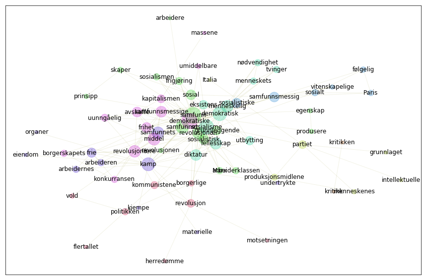

```python
gnl.show_graph(G, spread = 0.5, fontsize=12)
```

```python
bok = nb.pure_urn(bøker)[10]
nb.metadata(bok)
```

```
[[2016060808149,
  'Lenin, V.I.',
  1982,
  'To slags taktikk for sosialdemokratiet i den demokratiske revolusjon',
  '',
  'Falken',
  'notfiction',
  'a8f42f0a23529126ab6873ad4f8d8bc5',
  'nob',
  'rus']]
```

```python
R = nb.navn(bok)
R
```

```
{'Abt': 2,
 'Akimov': 3,
 'Altså': 3,
 'Arbeit': 3,
 'Bakunisten': 2,
 'Bd': 2,
 'Bebel': 4,
 'Bebels': 3,
 'Berlin': 4,
 'Bernstein': 2,
 'Born': 10,
 'Borns': 4,
 'Brentanosk': 2,
 'Bryssel': 2,
 'Bulygin': 3,
 'Bulygins': 2,
 'Buttermilch': 3,
 'Både': 2,
 'Camphausen': 4,
 'Co': 4,
 'Credo': 5,
 'Dag': 4,
 'Delo': 4,
 'Dem': 2,
 'Die': 3,
 'Dni': 2,
 'Engels': 40,
 'Erfurt-programmet': 2,
 'Europa': 12,
 'Forbundet': 4,
 'Forlag': 5,
 'Forord': 2,
 'Frankfurt': 5,
 'Frankfurt-parlamentet': 2,
 'Frankfurter': 3,
 'Frankrike': 3,
 'Frankrikes': 2,
 'Franz': 2,
 'Friedrich': 3,
 'Gapon': 2,
```

[output cut: 78 more lines]

```
 'Svarte': 5,
 'Sveits': 2,
 'Syn': 2,
 'Thiers': 2,
 'Tiflis': 4,
 'To': 16,
 'Tovaristsj': 2,
 'Tsjornyj': 3,
 'Tyskland': 7,
 'Tysklands': 4,
 'Vedomosti': 4,
 'Vperjod': 21,
 'Våger': 3,
 'Zeitung': 20,
 'Zur': 2}
```

```python
RN = nb.check_navn(R, limit=2)
```

```python
RN
```

```
{'Akimov': 3,
 'Altså': 3,
 'Arbeit': 3,
 'Bebel': 4,
 'Bebels': 3,
 'Berlin': 4,
 'Born': 10,
 'Borns': 4,
 'Bulygin': 3,
 'Buttermilch': 3,
 'Camphausen': 4,
 'Co': 4,
 'Credo': 5,
 'Dag': 4,
 'Delo': 4,
 'Die': 3,
 'Engels': 40,
 'Europa': 12,
 'Forbundet': 4,
 'Forlag': 5,
 'Frankfurt': 5,
 'Frankfurter': 3,
 'Frankrike': 3,
 'Friedrich': 3,
 'Geneve': 4,
 'Gierke': 3,
 'Généve': 3,
 'Hansemann': 4,
 'Hundrer': 3,
 'Iskra': 58,
 'Karl': 4,
 'Kaukasus': 3,
 'Kautsky': 4,
 'Kautskys': 3,
 'Kommunistenes': 3,
 'Lenin': 35,
 'Lenins': 14,
 'London': 3,
 'Louis': 3,
 'Martynov': 21,
```

[output cut: 32 more lines]

```
 'St': 11,
 'Starovers': 4,
 'Stephan': 4,
 'Struve': 55,
 'Struves': 9,
 'Svarte': 5,
 'Tiflis': 4,
 'To': 16,
 'Tsjornyj': 3,
 'Tyskland': 7,
 'Tysklands': 4,
 'Vedomosti': 4,
 'Vperjod': 21,
 'Våger': 3,
 'Zeitung': 20}
```

```python
GR = nb.make_network_graph(bok, RN)
```

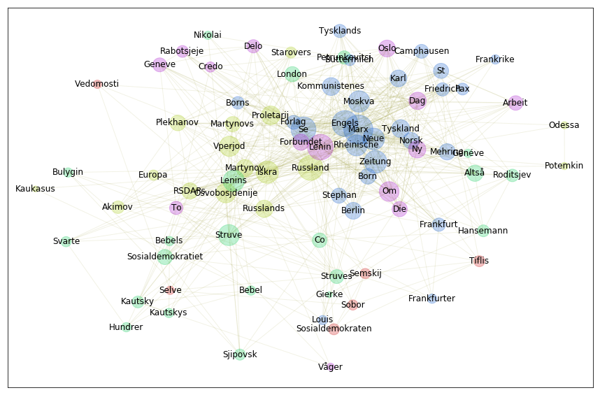

```python
gnl.show_graph(GR,  spread = 1.2, fontsize=12)
```

```python
nb.central_betweenness_characters(GR, 20)
```

```
[('Marx', 0.13804543220694962),
 ('Russland', 0.11694607071919431),
 ('Lenin', 0.08763987288518828),
 ('Struve', 0.07659329374620469),
 ('Iskra', 0.07107525896487288),
 ('Lenins', 0.07096451284164149),
 ('Se', 0.06300013087696128),
 ('Engels', 0.04912060568288558),
 ('Osvobosjdenije', 0.044561847028464954),
 ('Zeitung', 0.03069480661813742),
 ('Moskva', 0.027040358825108364),
 ('Martynov', 0.025707996274026146),
 ('Proletarij', 0.02270979180105311),
 ('Vperjod', 0.017699479252561098),
 ('Neue', 0.016595266424980312),
 ('Om', 0.013711858585814286),
 ('Rheinische', 0.013559616172493618),
 ('Roditsjev', 0.01334887441614568),
 ('To', 0.01325717164015794),
 ('Hansemann', 0.011140598450146406)]
```

```python
nb.central_characters(GR, 20)
```

```
[('Marx', 0.5783132530120483),
 ('Engels', 0.45783132530120485),
 ('Lenin', 0.44578313253012053),
 ('Russland', 0.42168674698795183),
 ('Se', 0.42168674698795183),
 ('Zeitung', 0.3493975903614458),
 ('Iskra', 0.3373493975903615),
 ('Neue', 0.3253012048192771),
 ('Moskva', 0.3132530120481928),
 ('Lenins', 0.3132530120481928),
 ('Rheinische', 0.30120481927710846),
 ('Struve', 0.30120481927710846),
 ('Vperjod', 0.27710843373493976),
 ('Osvobosjdenije', 0.26506024096385544),
 ('Om', 0.26506024096385544),
 ('Proletarij', 0.24096385542168675),
 ('Tyskland', 0.21686746987951808),
 ('Kommunistenes', 0.21686746987951808),
 ('Martynov', 0.20481927710843376),
 ('Russlands', 0.20481927710843376)]
```